# Classifying Income Level: A Statistical Analysis of the Adult Census Dataset

Kyagambiddwa J Kelly, 2300710452, 23/U/10452/PS

2026-04-23

# 1. Introduction

## 1.1 Project Overview

This report presents a comprehensive statistical analysis of the UCI Adult Income dataset, commonly known as the “Census Income” dataset. The primary objective is to build robust classification models that predict whether an individual’s annual income exceeds $50,000 based on demographic and employment characteristics. The analysis explores both Decision Tree and Naive Bayes algorithms, with careful attention to data preprocessing, outlier treatment, and class imbalance.

## 1.2 Dataset Description

| Variable Name | Description | Type |
| --- | --- | --- |
| age | Age of individual | Continuous |
| workclass | Employment type | Categorical |
| fnlwgt | Final sampling weight | Continuous |
| education | Highest education level | Categorical |
| education_num | Education level in numeric form | Continuous |
| marital_status | Marital status | Categorical |
| occupation | Job occupation type | Categorical |
| relationship | Family relationship status | Categorical |
| race | Race of individual | Categorical |
| sex | Gender | Categorical |
| capital_gain | Capital gains received | Continuous |
| capital_loss | Capital losses incurred | Continuous |
| hours_per_week | Hours worked per week | Continuous |
| native_country | Country of origin | Categorical |
| income | Income bracket (<=50K or >50K) | Binary Target |

# 2. Data Preprocessing and Cleaning

```r
# This chunk checks if we should run preprocessing
if(skip_preprocessing) {
  # Skipping preprocessing sections (2.1 through 3.6) because cleaned dataset exists
} else {
  # Running full preprocessing pipeline
}
```

## 2.1 Loading and Initial Inspection

```r
# Define column names based on dataset documentation
columns <- c("age", "workclass", "fnlwgt", "education", "education_num",
             "marital_status", "occupation", "relationship", "race", "sex",
             "capital_gain", "capital_loss", "hours_per_week",
             "native_country", "income")

# Load the dataset
adult_data <- read.csv('adult.data',
                       header = FALSE,
                       col.names = columns,
                       strip.white = TRUE,
                       na.strings = "?")

# Display basic information
print(paste("Dataset dimensions:", dim(adult_data)[1], "rows and", dim(adult_data)[2], "columns"))
print("\nFirst few rows of the dataset:")
print(head(adult_data, 3))

# Data structure overview
print("\nData structure summary:")
str(adult_data, max.level = 1, give.attr = FALSE)
```

## 2.2 Handling Duplicate Records

Duplicate records can artificially inflate the importance of certain observations and lead to overfitting.

```r
# Count duplicates
duplicates_count <- sum(duplicated(adult_data))
print(paste("Number of duplicate records:", duplicates_count))

# Remove duplicates if any exist
if(duplicates_count > 0) {
  adult_data <- unique(adult_data)
  print(paste("Duplicates removed. New dimensions:", dim(adult_data)[1], "x", dim(adult_data)[2]))
} else {
  print("No duplicates found in the dataset.")
}

# Verify no duplicates remain
print(paste("Final duplicate check:", sum(duplicated(adult_data))))
```

## 2.3 Missing Data Analysis

The dataset uses “?” to denote missing values, which we’ve already converted to NA during import.

```r
# Calculate missing values per column
missing_counts <- colSums(is.na(adult_data))
missing_df <- data.frame(
  Variable = names(missing_counts),
  Missing_Count = missing_counts,
  Missing_Percentage = round(missing_counts / nrow(adult_data) * 100, 2)
)

# Display only columns with missing values
missing_with_data <- missing_df[missing_df$Missing_Count > 0, ]

if(nrow(missing_with_data) > 0) {
  knitr::kable(missing_with_data,
        caption = "Table 1: Missing Values by Column",
        col.names = c("Variable", "Missing Count", "Missing Percentage"),
        digits = 2)
} else {
  print("No missing values found in the dataset.")
}
```

### Statistical Justification for KNN Imputation

Rather than using listwise deletion (removing all rows with missing values), which can introduce bias if data is not Missing Completely at Random (MCAR), we employ K-Nearest Neighbors imputation. This method:

1. Preserves the underlying distribution of the data
2. Uses information from similar observations to estimate missing values
3. Is suitable for both categorical and numerical variables
4. Maintains statistical power by retaining all observations

```r
# Check if imputation is needed
if(sum(is.na(adult_data)) > 0) {
  # Perform kNN imputation (k=5)
  adult_imputed <- kNN(adult_data,
                       variable = c("workclass", "occupation", "native_country"),
                       k = 5)

  # Remove the logical flag columns added by VIM
  adult_final <- adult_imputed[, 1:15]
  print("KNN imputation completed with k = 5")
} else {
  adult_final <- adult_data
  print("No imputation needed - dataset is complete.")
}

# Verify that no missing values remain
final_missing <- colSums(is.na(adult_final))
print(paste("Missing values after processing:", sum(final_missing)))
```

# 3. Outlier Analysis and Treatment

## 3.1 Outlier Detection Function

```r
# Function to count outliers using IQR method for numeric columns
count_outliers <- function(data, columns = NULL) {
  if (is.null(columns)) {
    columns <- names(data)[sapply(data, is.numeric)]
  }

  outlier_counts <- sapply(columns, function(col) {
    x <- data[[col]]
    x_clean <- x[!is.na(x)]
    if (length(x_clean) == 0) return(NA)
    Q1 <- quantile(x_clean, 0.25, na.rm = TRUE)
    Q3 <- quantile(x_clean, 0.75, na.rm = TRUE)
    IQR_val <- Q3 - Q1
    lower <- Q1 - 1.5 * IQR_val
    upper <- Q3 + 1.5 * IQR_val
    sum(x > upper | x < lower, na.rm = TRUE)
  })

  n_non_na <- sapply(data[columns], function(x) sum(!is.na(x)))

  data.frame(
    Variable = columns,
    Outliers = outlier_counts,
    Total_NonNA = n_non_na,
    Percent_Outlier = round(100 * outlier_counts / n_non_na, 2)
  )
}

# Define numeric columns of interest
numeric_vars <- c("age", "fnlwgt", "education_num", "capital_gain",
                  "capital_loss", "hours_per_week")
```

## 3.2 Outlier Analysis Across Processing Stages

```r
# Stage 0: Raw data
outliers_stage0 <- count_outliers(adult_data, numeric_vars)
outliers_stage0$Stage <- "Raw Data"

# Stage 1: After duplicate removal
adult_no_dupes <- adult_data
outliers_stage1 <- count_outliers(adult_no_dupes, numeric_vars)
outliers_stage1$Stage <- "After Duplicate Removal"

# Stage 2: After imputation
outliers_stage2 <- count_outliers(adult_final, numeric_vars)
outliers_stage2$Stage <- "After Imputation"

# Combine for comparison
outlier_summary <- rbind(outliers_stage0, outliers_stage1, outliers_stage2)

# Create comparison table
outlier_wide <- outlier_summary %>%
  select(Stage, Variable, Outliers, Percent_Outlier) %>%
  pivot_wider(names_from = Stage,
              values_from = c(Outliers, Percent_Outlier),
              names_glue = "{Stage}_{.value}")

knitr::kable(outlier_wide,
      caption = "Table 2: Outlier Counts Across Processing Stages",
      digits = 2)
```

## 3.3 Visual Outlier Comparison

```r
# Create boxplots comparing before and after imputation
par(mfrow = c(2, 3), mar = c(4, 4, 2, 1), oma = c(0, 0, 2, 0))

for (var in numeric_vars) {
  boxplot(adult_no_dupes[[var]], adult_final[[var]],
          names = c("Before Imputation", "After Imputation"),
          main = var,
          col = c(colors$primary, colors$success),
          border = colors$dark,
          outline = TRUE,
          cex.main = 0.9,
          cex.axis = 0.8)
}

mtext("Outlier Comparison: Before vs After Imputation",
      outer = TRUE, cex = 1.2, col = colors$dark)
```

## 3.4 Detailed Outlier Analysis

```r
# Function for detailed outlier analysis
analyze_outliers <- function(data, var, threshold = 3) {
  x <- data[[var]]
  mean_val <- mean(x, na.rm = TRUE)
  sd_val <- sd(x, na.rm = TRUE)
  z_scores <- abs((x - mean_val) / sd_val)
  extreme_outliers <- which(z_scores > threshold)

  cat(sprintf("\n### %s Analysis:\n", var))
  cat(sprintf("- Mean: %.2f, SD: %.2f\n", mean_val, sd_val))
  cat(sprintf("- Total outliers (IQR method): %d (%.2f%%)\n",
              sum(x > quantile(x, 0.75) + 1.5*IQR(x) | x < quantile(x, 0.25) - 1.5*IQR(x)),
              100 * sum(x > quantile(x, 0.75) + 1.5*IQR(x) | x < quantile(x, 0.25) - 1.5*IQR(x)) / length(x)))
  cat(sprintf("- Extreme outliers (|z| > %d): %d (%.2f%%)\n",
              threshold, length(extreme_outliers),
              100 * length(extreme_outliers) / length(x)))
  cat("- Top 10 most extreme values:\n")
  print(head(sort(x, decreasing = TRUE), 10))
  cat("\n")
}

# Analyze each numeric variable
for (var in numeric_vars) {
  analyze_outliers(adult_final, var)
}
```

## 3.5 Targeted Outlier Treatment

Based on the analysis, we apply variable-specific treatments:

```r
# Create a cleaned dataset
adult_cleaned <- adult_final

# 1. FNLWGT - Log transform (extreme sampling weights)
adult_cleaned$fnlwgt_log <- log(adult_final$fnlwgt)

# 2. CAPITAL_GAIN - Handle top-coded values (99999)
adult_cleaned$has_capital_gain <- as.integer(adult_final$capital_gain > 0)
adult_cleaned$capital_gain_log <- log1p(adult_final$capital_gain)

# 3. CAPITAL_LOSS - Handle top-coded values
adult_cleaned$has_capital_loss <- as.integer(adult_final$capital_loss > 0)
adult_cleaned$capital_loss_log <- log1p(adult_final$capital_loss)

# 4. HOURS_PER_WEEK - Winsorize at 1st and 99th percentile
hours_99th <- quantile(adult_final$hours_per_week, 0.99)
hours_1st <- quantile(adult_final$hours_per_week, 0.01)
adult_cleaned$hours_winsorized <- adult_final$hours_per_week
adult_cleaned$hours_winsorized[adult_cleaned$hours_winsorized > hours_99th] <- hours_99th
adult_cleaned$hours_winsorized[adult_cleaned$hours_winsorized < hours_1st] <- hours_1st

# 5. Create categorical version of hours
adult_cleaned$hours_category <- cut(adult_final$hours_per_week,
                                    breaks = c(0, 20, 40, 50, 60, 100),
                                    labels = c("Part-time", "Full-time",
                                              "Overtime", "Extreme", "Very Extreme"))

print("Outlier treatment completed:")
print("- Created log-transformed fnlwgt_log")
print("- Created capital_gain indicators (binary + log)")
print("- Created capital_loss indicators (binary + log)")
print(paste("- Winsorized hours to [", hours_1st, ", ", hours_99th, "]", sep = ""))
print("- Created hours_category factor")
```

## 3.6 Saving Cleaned Dataset

After completing all preprocessing steps (duplicate removal, KNN imputation, and outlier treatment), we save the cleaned dataset for future use. This ensures reproducibility and allows other analyses to use the same preprocessed data.

```r
# Create timestamp for versioning
timestamp <- format(Sys.Date(), "%Y%m%d")

# Save the fully processed dataset
final_dataset <- adult_cleaned

# Ensure all factor variables are properly set
factor_vars <- c("workclass", "education", "marital_status", "occupation",
                 "relationship", "race", "sex", "native_country", "income",
                 "hours_category", "has_capital_gain", "has_capital_loss")
for(var in factor_vars) {
  if(var %in% names(final_dataset)) {
    final_dataset[[var]] <- as.factor(final_dataset[[var]])
  }
}

# Save in multiple formats
rds_filename <- paste0("adult_census_cleaned_", timestamp, ".rds")
saveRDS(final_dataset, rds_filename)

# Also save the most recent version with a consistent name for easy loading
saveRDS(final_dataset, "adult_census_cleaned_latest.rds")

print("Cleaned dataset saved as 'adult_census_cleaned_latest.rds'")
```

# 4. Exploratory Data Analysis

## 4.0 Loading Cleaned Dataset

```r
# Load the most recently cleaned dataset
# This ensures we're working with the fully preprocessed data
if(file.exists("adult_census_cleaned_latest.rds")) {
  cleaned_data <- readRDS("adult_census_cleaned_latest.rds")
  print("Loaded cleaned dataset from 'adult_census_cleaned_latest.rds'")
} else {
  # Fallback to the timestamped version if latest doesn't exist
  timestamp <- format(Sys.Date(), "%Y%m%d")
  filename <- paste0("adult_census_cleaned_", timestamp, ".rds")
  if(file.exists(filename)) {
    cleaned_data <- readRDS(filename)
    print(paste("Loaded cleaned dataset from", filename))
  } else {
    stop("No cleaned dataset found! Please run preprocessing sections first.")
  }
}
```

```
## [1] "Loaded cleaned dataset from 'adult_census_cleaned_latest.rds'"
```

```r
# Create separate data objects for different analyses
adult_final <- cleaned_data[, 1:15]  # Original variables only
adult_cleaned <- cleaned_data  # Full dataset with engineered features

# Define variable groups for later use
numeric_vars <- c("age", "fnlwgt", "education_num", "capital_gain",
                  "capital_loss", "hours_per_week")
categorical_cols <- c("workclass", "education", "marital_status", "occupation",
                      "relationship", "race", "sex", "native_country")
char_cols <- c(categorical_cols, "income")

print("\nDataset loaded successfully:")
```

```
## [1] "\nDataset loaded successfully:"
```

```r
print(paste("   - Rows:", nrow(cleaned_data)))
```

```
## [1] "   - Rows: 32537"
```

```r
print(paste("   - Columns:", ncol(cleaned_data)))
```

```
## [1] "   - Columns: 22"
```

```r
print(paste("   - Original variables:", ncol(adult_final)))
```

```
## [1] "   - Original variables: 15"
```

```r
print(paste("   - Engineered features:", ncol(adult_cleaned) - 15))
```

```
## [1] "   - Engineered features: 7"
```

## 4.1 Class Distribution Analysis

```r
# Convert income to factor
adult_final$income <- as.factor(adult_final$income)

# Count occurrences
class_counts <- table(adult_final$income)
names(class_counts) <- c("<=50K", ">50K")
class_percentages <- prop.table(class_counts) * 100

# Create summary table
distribution_table <- rbind(
  Count = class_counts,
  Percentage = round(class_percentages, 2)
)

knitr::kable(distribution_table,
      caption = "Table 3: Class Distribution in Adult Dataset",
      col.names = c("<=50K", ">50K"))
```

Table 3: Class Distribution in Adult Dataset

|  | <=50K | >50K |
| --- | --- | --- |
| Count | 24698.00 | 7839.00 |
| Percentage | 75.91 | 24.09 |

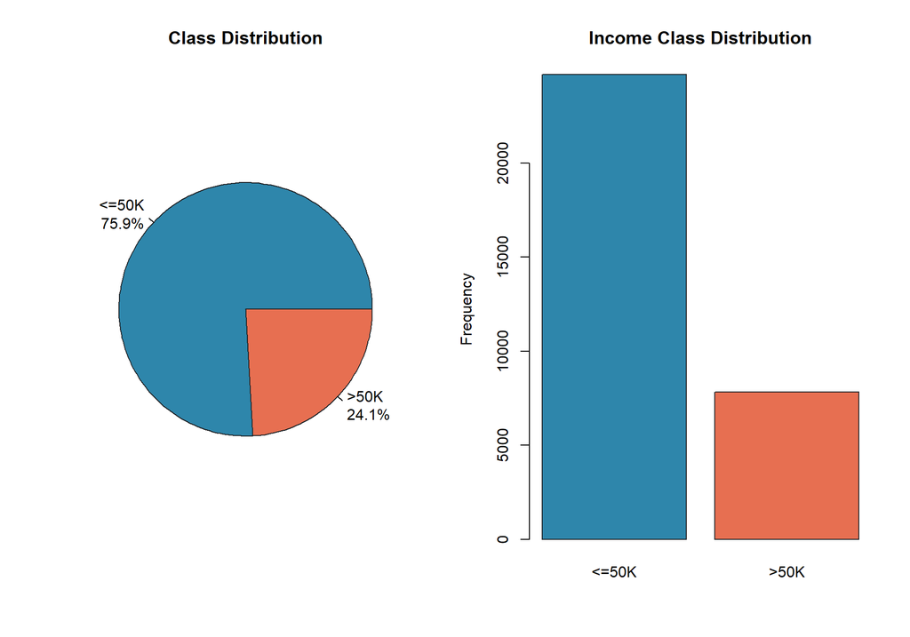

```r
# Visualize class distribution
par(mfrow = c(1, 2))
pie(class_counts,
    labels = paste0(names(class_counts), "\n", round(class_percentages, 1), "%"),
    main = "Class Distribution",
    col = c(colors$primary, colors$danger),
    border = colors$dark)

barplot(class_counts,
        main = "Income Class Distribution",
        ylab = "Frequency",
        col = c(colors$primary, colors$danger),
        names.arg = c("<=50K", ">50K"),
        border = colors$dark)
```

**Key Finding:** The dataset is severely imbalanced with 75.91% of individuals earning ≤50K and only 24.09% earning >50K. This imbalance must be addressed for reliable classification.

## 4.2 Correlation Analysis

```r
# Convert character columns to factors for analysis
adult_final[char_cols] <- lapply(adult_final[char_cols], as.factor)

# Numeric correlation matrix
cor_matrix <- cor(adult_final[, numeric_vars], use = "complete.obs")
knitr::kable(round(cor_matrix, 3),
      caption = "Table 4: Numeric Variable Correlations")
```

Table 4: Numeric Variable Correlations

|  | age | fnlwgt | education_num | capital_gain | capital_loss | hours_per_week |
| --- | --- | --- | --- | --- | --- | --- |
| age | 1.000 | -0.076 | 0.036 | 0.078 | 0.058 | 0.069 |
| fnlwgt | -0.076 | 1.000 | -0.043 | 0.000 | -0.010 | -0.019 |
| education_num | 0.036 | -0.043 | 1.000 | 0.123 | 0.080 | 0.148 |
| capital_gain | 0.078 | 0.000 | 0.123 | 1.000 | -0.032 | 0.078 |
| capital_loss | 0.058 | -0.010 | 0.080 | -0.032 | 1.000 | 0.054 |
| hours_per_week | 0.069 | -0.019 | 0.148 | 0.078 | 0.054 | 1.000 |

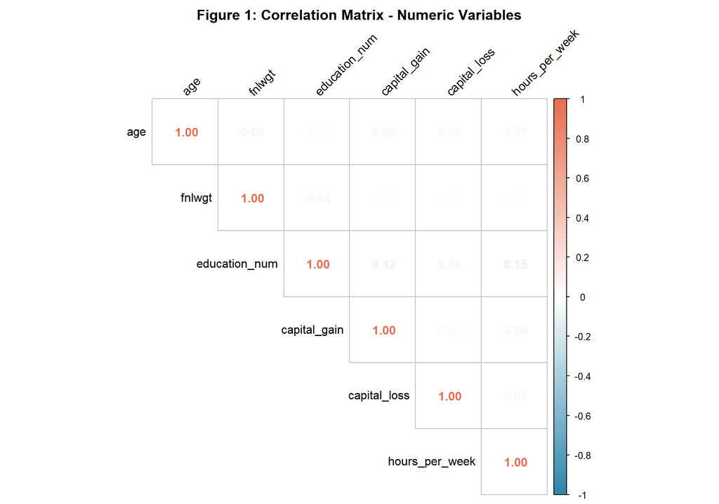

```r
# Visualize correlations
corrplot(cor_matrix, method = "number", type = "upper",
         tl.col = "black", tl.srt = 45,
         col = colorRampPalette(c(colors$primary, "white", colors$danger))(100),
         title = "Figure 1: Correlation Matrix - Numeric Variables",
         mar = c(0, 0, 2, 0))
```

## 4.3 Categorical Variable Associations

```r
# Function to calculate Cramer's V
cramers_v <- function(x, y) {
  tbl <- table(x, y)
  chi2 <- chisq.test(tbl, simulate.p.value = TRUE)$statistic
  n <- sum(tbl)
  min_dim <- min(dim(tbl)) - 1
  v <- sqrt(chi2 / (n * min_dim))
  return(as.numeric(v))
}

# Create association matrix
n_cat <- length(categorical_cols)
cat_assoc <- matrix(0, n_cat, n_cat)
rownames(cat_assoc) <- categorical_cols
colnames(cat_assoc) <- categorical_cols

for (i in 1:n_cat) {
  for (j in 1:n_cat) {
    if (i != j) {
      cat_assoc[i, j] <- cramers_v(adult_final[[categorical_cols[i]]],
                                   adult_final[[categorical_cols[j]]])
    }
  }
}

knitr::kable(round(cat_assoc, 3),
      caption = "Table 5: Categorical Variable Associations (Cramer's V)")
```

Table 5: Categorical Variable Associations (Cramer’s V)

|  | workclass | education | marital_status | occupation | relationship | race | sex | native_country |
| --- | --- | --- | --- | --- | --- | --- | --- | --- |
| workclass | 0.000 | 0.106 | 0.079 | 0.196 | 0.093 | 0.056 | 0.146 | 0.045 |
| education | 0.106 | 0.000 | 0.092 | 0.197 | 0.123 | 0.075 | 0.096 | 0.134 |
| marital_status | 0.079 | 0.092 | 0.000 | 0.133 | 0.488 | 0.084 | 0.462 | 0.072 |
| occupation | 0.196 | 0.197 | 0.133 | 0.000 | 0.179 | 0.086 | 0.444 | 0.073 |
| relationship | 0.093 | 0.123 | 0.488 | 0.179 | 0.000 | 0.098 | 0.649 | 0.085 |
| race | 0.056 | 0.075 | 0.084 | 0.086 | 0.098 | 0.000 | 0.118 | 0.397 |
| sex | 0.146 | 0.096 | 0.462 | 0.444 | 0.649 | 0.118 | 0.000 | 0.069 |
| native_country | 0.045 | 0.134 | 0.072 | 0.073 | 0.085 | 0.397 | 0.069 | 0.000 |

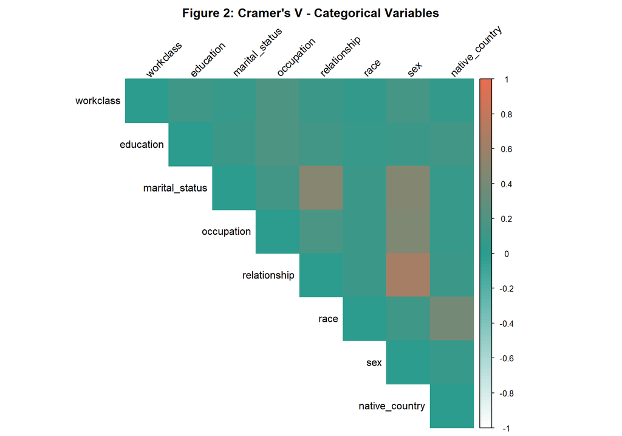

```r
# Visualize associations
corrplot(cat_assoc, method = "color", type = "upper",
         tl.col = "black", tl.srt = 45,
         title = "Figure 2: Cramer's V - Categorical Variables",
         col = colorRampPalette(c("white", colors$success, colors$danger))(100),
         mar = c(0, 0, 2, 0))
```

```r
# Find highly associated pairs
high_assoc <- which(cat_assoc > 0.5 & upper.tri(cat_assoc), arr.ind = TRUE)
if(nrow(high_assoc) > 0) {
  cat("\nHighly associated categorical pairs (Cramer's V > 0.5):\n")
  for(i in 1:nrow(high_assoc)) {
    cat(sprintf("- %s and %s: %.3f\n",
                rownames(cat_assoc)[high_assoc[i,1]],
                colnames(cat_assoc)[high_assoc[i,2]],
                cat_assoc[high_assoc[i,1], high_assoc[i,2]]))
  }
}
```

```
##
## Highly associated categorical pairs (Cramer's V > 0.5):
## - relationship and sex: 0.649
```

## 4.4 Target Variable Association

```r
# Numeric variables - Point Biserial Correlation
numeric_income_cor <- sapply(numeric_vars, function(var) {
  cor(as.numeric(adult_final$income), adult_final[[var]], method = "pearson")
})
names(numeric_income_cor) <- numeric_vars
numeric_income_cor <- sort(abs(numeric_income_cor), decreasing = TRUE)

# Categorical variables - Cramer's V with Income
categorical_income_assoc <- sapply(categorical_cols, function(var) {
  cramers_v(adult_final[[var]], adult_final$income)
})
names(categorical_income_assoc) <- categorical_cols
categorical_income_assoc <- sort(categorical_income_assoc, decreasing = TRUE)

# Create combined importance dataframe
importance_df <- data.frame(
  Variable = c(names(numeric_income_cor), names(categorical_income_assoc)),
  Importance = c(numeric_income_cor, categorical_income_assoc),
  Type = c(rep("Numeric", length(numeric_income_cor)),
           rep("Categorical", length(categorical_income_assoc)))
) %>% arrange(desc(Importance))

knitr::kable(head(importance_df, 10),
      caption = "Table 6: Top 10 Features by Association with Income",
      digits = 3)
```

Table 6: Top 10 Features by Association with Income

|  | Variable | Importance | Type |
| --- | --- | --- | --- |
| relationship | relationship | 0.454 | Categorical |
| marital_status | marital_status | 0.447 | Categorical |
| education | education | 0.369 | Categorical |
| occupation | occupation | 0.346 | Categorical |
| education_num | education_num | 0.335 | Numeric |
| age | age | 0.234 | Numeric |
| hours_per_week | hours_per_week | 0.230 | Numeric |
| capital_gain | capital_gain | 0.223 | Numeric |
| sex | sex | 0.216 | Categorical |
| workclass | workclass | 0.171 | Categorical |

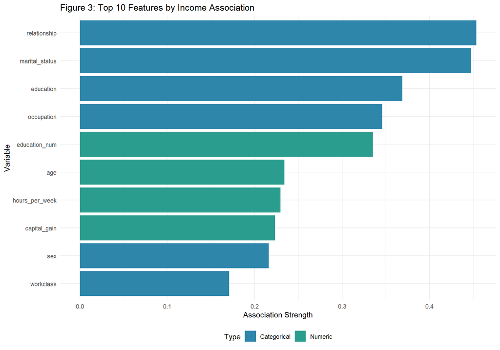

```r
# Visualize feature importance
ggplot(head(importance_df, 10),
       aes(x = reorder(Variable, Importance), y = Importance, fill = Type)) +
  geom_bar(stat = "identity") +
  coord_flip() +
  scale_fill_manual(values = c(colors$primary, colors$success)) +
  labs(title = "Figure 3: Top 10 Features by Income Association",
       x = "Variable", y = "Association Strength") +
  theme_minimal() +
  theme(legend.position = "bottom")
```

# 5. Feature Selection for Different Algorithms

## 5.1 Decision Tree Feature Selection

Decision trees are robust to correlated features and can handle both numeric and categorical variables well.

```r
dt_features <- importance_df$Variable[1:min(10, nrow(importance_df))]
cat("Top 10 features for Decision Tree:\n")
```

```
## Top 10 features for Decision Tree:
```

```r
cat(paste("  ", 1:length(dt_features), ".", dt_features, "\n"))
```

```
##    1 . relationship
##     2 . marital_status
##     3 . education
##     4 . occupation
##     5 . education_num
##     6 . age
##     7 . hours_per_week
##     8 . capital_gain
##     9 . sex
##     10 . workclass
```

```r
cat("\nDecision Tree Formula:\n")
```

```
##
## Decision Tree Formula:
```

```r
cat(sprintf("income ~ %s\n", paste(dt_features, collapse = " + ")))
```

```
## income ~ relationship + marital_status + education + occupation + education_num + age + hours_per_week + capital_gain + sex + workclass
```

## 5.2 Naive Bayes Feature Selection

Naive Bayes assumes feature independence, requiring transformed features for optimal performance.

```r
nb_features <- c("age", "fnlwgt_log", "education_num",
                 "capital_gain_log", "capital_loss_log",
                 "hours_winsorized", "has_capital_gain",
                 "has_capital_loss", "hours_category",
                 categorical_cols)

cat("Naive Bayes uses transformed features:\n")
```

```
## Naive Bayes uses transformed features:
```

```r
cat(paste("  •", nb_features, collapse = "\n"))
```

```
##   • age
##   • fnlwgt_log
##   • education_num
##   • capital_gain_log
##   • capital_loss_log
##   • hours_winsorized
##   • has_capital_gain
##   • has_capital_loss
##   • hours_category
##   • workclass
##   • education
##   • marital_status
##   • occupation
##   • relationship
##   • race
##   • sex
##   • native_country
```

## 5.3 Creating Specialized Datasets

```r
# Use the loaded data objects
# adult_final and adult_cleaned are already loaded from the saved dataset

# Dataset for Decision Trees (original data)
adult_for_trees <- adult_final

# Dataset for Naive Bayes (transformed data)
adult_for_nb <- adult_cleaned[, c("age", "fnlwgt_log", "education_num",
                                   "capital_gain_log", "capital_loss_log",
                                   "hours_winsorized", "has_capital_gain",
                                   "has_capital_loss", "hours_category",
                                   categorical_cols, "income")]

# Convert factors for both datasets
adult_for_trees[char_cols] <- lapply(adult_for_trees[char_cols], as.factor)
adult_for_nb[c(categorical_cols, "hours_category")] <-
  lapply(adult_for_nb[c(categorical_cols, "hours_category")], as.factor)

cat("Specialized datasets created from saved data:\n")
```

```
## Specialized datasets created from saved data:
```

```r
cat("- adult_for_trees:", nrow(adult_for_trees), "rows,",
    ncol(adult_for_trees), "columns\n")
```

```
## - adult_for_trees: 32537 rows, 15 columns
```

```r
cat("- adult_for_nb:", nrow(adult_for_nb), "rows,",
    ncol(adult_for_nb), "columns\n")
```

```
## - adult_for_nb: 32537 rows, 18 columns
```

# 6. Decision Tree Modeling

## 6.1 Data Split

```r
set.seed(256)
sample_idx <- sample(1:nrow(adult_for_trees), 0.8 * nrow(adult_for_trees))
train_tree <- adult_for_trees[sample_idx, ]
test_tree <- adult_for_trees[-sample_idx, ]

cat("Training set:", nrow(train_tree), "rows\n")
```

```
## Training set: 26029 rows
```

```r
cat("Testing set:", nrow(test_tree), "rows\n")
```

```
## Testing set: 6508 rows
```

## 6.2 Initial Decision Tree

```r
model_tree <- rpart(income ~ . - fnlwgt,
                    data = train_tree,
                    method = "class",
                    control = rpart.control(cp = 0.01))

# Predictions
pred_tree <- predict(model_tree, test_tree, type = "class")
pred_tree <- factor(pred_tree, levels = levels(test_tree$income))

# Evaluation
eval_tree <- confusionMatrix(pred_tree, test_tree$income)

# Display results
print(eval_tree)
```

```
## Confusion Matrix and Statistics
##
##           Reference
## Prediction <=50K >50K
##      <=50K  4696  777
##      >50K    254  781
##
##                Accuracy : 0.8416
##                  95% CI : (0.8325, 0.8504)
##     No Information Rate : 0.7606
##     P-Value [Acc > NIR] : < 2.2e-16
##
##                   Kappa : 0.5084
##
##  Mcnemar's Test P-Value : < 2.2e-16
##
##             Sensitivity : 0.9487
##             Specificity : 0.5013
##          Pos Pred Value : 0.8580
##          Neg Pred Value : 0.7546
##              Prevalence : 0.7606
##          Detection Rate : 0.7216
##    Detection Prevalence : 0.8410
##       Balanced Accuracy : 0.7250
##
##        'Positive' Class : <=50K
##
```

```r
# Extract metrics
initial_metrics <- data.frame(
  Metric = c("Accuracy", "Sensitivity (<=50K)", "Specificity (>50K)",
             "Balanced Accuracy", "P-Value"),
  Value = c(
    round(eval_tree$overall["Accuracy"] * 100, 2),
    round(eval_tree$byClass["Sensitivity"] * 100, 2),
    round(eval_tree$byClass["Specificity"] * 100, 2),
    round(eval_tree$byClass["Balanced Accuracy"] * 100, 2),
    format(eval_tree$overall["AccuracyPValue"], scientific = TRUE)
  )
)

knitr::kable(initial_metrics,
      caption = "Table 7: Initial Decision Tree Performance")
```

Table 7: Initial Decision Tree Performance

|  | Metric | Value |
| --- | --- | --- |
| Accuracy | Accuracy | 84.16 |
| Sensitivity | Sensitivity (<=50K) | 94.87 |
| Specificity | Specificity (>50K) | 50.13 |
| Balanced Accuracy | Balanced Accuracy | 72.5 |
| AccuracyPValue | P-Value | 5.594719e-58 |

## 6.3 Visualizing Initial Tree

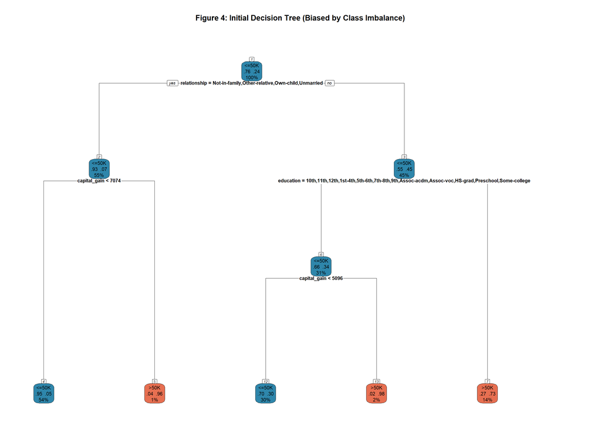

```r
rpart.plot(model_tree,
           type = 2,
           extra = 104,
           fallen.leaves = TRUE,
           main = "Figure 4: Initial Decision Tree (Biased by Class Imbalance)",
           box.palette = list(colors$primary, colors$danger),
           nn = TRUE,
           varlen = 0,
           faclen = 0,
           cex = 0.7,
           under.cex = 0.7)
```

## 6.4 Balanced Decision Tree

```r
# Downsample training data
set.seed(256)
train_balanced_tree <- downSample(x = train_tree[, -which(names(train_tree) == "income")],
                                   y = train_tree$income,
                                   yname = "income")

# Train balanced model
model_tree_balanced <- rpart(income ~ . - fnlwgt,
                             data = train_balanced_tree,
                             method = "class",
                             control = rpart.control(cp = 0.01, maxdepth = 4))

# Predict with custom threshold
prob_pred <- predict(model_tree_balanced, test_tree, type = "prob")
custom_threshold <- 0.7
pred_custom <- ifelse(prob_pred[, ">50K"] >= custom_threshold, ">50K", "<=50K")
pred_tree_balanced <- factor(pred_custom, levels = levels(test_tree$income))

# Evaluation
eval_tree_balanced <- confusionMatrix(pred_tree_balanced, test_tree$income)

# Display results
print(eval_tree_balanced)
```

```
## Confusion Matrix and Statistics
##
##           Reference
## Prediction <=50K >50K
##      <=50K  4251  458
##      >50K    699 1100
##
##                Accuracy : 0.8222
##                  95% CI : (0.8127, 0.8314)
##     No Information Rate : 0.7606
##     P-Value [Acc > NIR] : < 2.2e-16
##
##                   Kappa : 0.5364
##
##  Mcnemar's Test P-Value : 1.716e-12
##
##             Sensitivity : 0.8588
##             Specificity : 0.7060
##          Pos Pred Value : 0.9027
##          Neg Pred Value : 0.6115
##              Prevalence : 0.7606
##          Detection Rate : 0.6532
##    Detection Prevalence : 0.7236
##       Balanced Accuracy : 0.7824
##
##        'Positive' Class : <=50K
##
```

```r
# Calculate additional metrics
balanced_metrics <- data.frame(
  Metric = c("Accuracy", "Sensitivity (<=50K)", "Specificity (>50K)",
             "Balanced Accuracy", "P-Value"),
  Value = c(
    round(eval_tree_balanced$overall["Accuracy"] * 100, 2),
    round(eval_tree_balanced$byClass["Sensitivity"] * 100, 2),
    round(eval_tree_balanced$byClass["Specificity"] * 100, 2),
    round(eval_tree_balanced$byClass["Balanced Accuracy"] * 100, 2),
    format(eval_tree_balanced$overall["AccuracyPValue"], scientific = TRUE)
  )
)

knitr::kable(balanced_metrics,
      caption = "Table 8: Balanced Decision Tree Performance")
```

Table 8: Balanced Decision Tree Performance

|  | Metric | Value |
| --- | --- | --- |
| Accuracy | Accuracy | 82.22 |
| Sensitivity | Sensitivity (<=50K) | 85.88 |
| Specificity | Specificity (>50K) | 70.6 |
| Balanced Accuracy | Balanced Accuracy | 78.24 |
| AccuracyPValue | P-Value | 1.302077e-33 |

## 6.5 Visualizing Balanced Tree

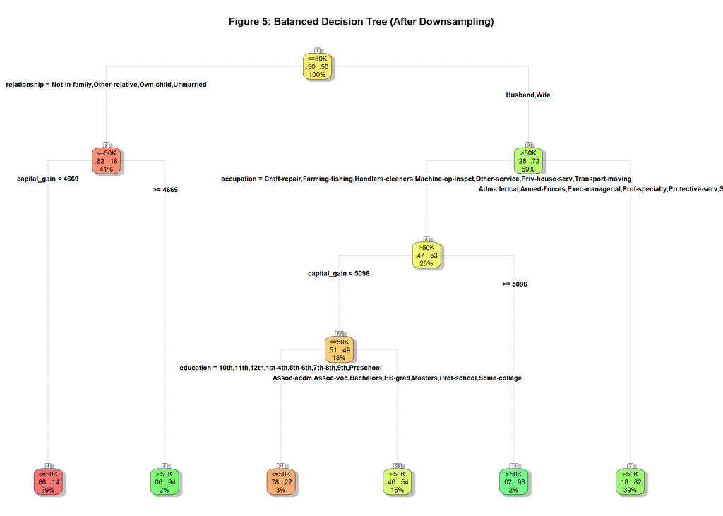

```r
rpart.plot(model_tree_balanced,
           type = 4,
           extra = 104,
           fallen.leaves = TRUE,
           main = "Figure 5: Balanced Decision Tree (After Downsampling)",
           box.palette = "RdYlGn",
           shadow.col = "gray",
           nn = TRUE,
           varlen = 0,
           faclen = 0,
           cex = 0.7,
           tweak = 1.1,
           under.cex = 0.7,
           branch.lty = 3)
```

# 7. Naive Bayes Modeling

## 7.1 Data Preparation

```r
set.seed(256)
sample_idx_nb <- sample(1:nrow(adult_for_nb), 0.8 * nrow(adult_for_nb))
train_nb <- adult_for_nb[sample_idx_nb, ]
test_nb <- adult_for_nb[-sample_idx_nb, ]

# Ensure income is a factor with consistent levels
train_nb$income <- as.factor(train_nb$income)
test_nb$income <- as.factor(test_nb$income)

cat("Naive Bayes Training set:", nrow(train_nb), "rows\n")
```

```
## Naive Bayes Training set: 26029 rows
```

```r
cat("Naive Bayes Testing set:", nrow(test_nb), "rows\n")
```

```
## Naive Bayes Testing set: 6508 rows
```

```r
cat("\nTraining set class distribution:\n")
```

```
##
## Training set class distribution:
```

```r
print(prop.table(table(train_nb$income)))
```

```
##
##     <=50K      >50K
## 0.7586922 0.2413078
```

```r
cat("\nTesting set class distribution:\n")
```

```
##
## Testing set class distribution:
```

```r
print(prop.table(table(test_nb$income)))
```

```
##
##     <=50K      >50K
## 0.7606023 0.2393977
```

## 7.2 Naive Bayes Formula

```r
# Create formula excluding any non-predictor columns
nb_features <- setdiff(names(adult_for_nb), "income")
nb_formula <- as.formula(paste("income ~", paste(nb_features, collapse = " + ")))
cat("Naive Bayes Formula:\n")
```

```
## Naive Bayes Formula:
```

```r
print(nb_formula)
```

```
## income ~ age + fnlwgt_log + education_num + capital_gain_log +
##     capital_loss_log + hours_winsorized + has_capital_gain +
##     has_capital_loss + hours_category + workclass + education +
##     marital_status + occupation + relationship + race + sex +
##     native_country
```

## 7.3 Original Naive Bayes

```r
# Train Naive Bayes model
nb_model <- naiveBayes(nb_formula, data = train_nb)

# Make predictions
pred_nb <- predict(nb_model, test_nb)

# Ensure predictions are factors with the same levels as test data
pred_nb <- factor(pred_nb, levels = levels(test_nb$income))

# Evaluation
eval_nb <- confusionMatrix(pred_nb, test_nb$income)

# Display results
print(eval_nb)
```

```
## Confusion Matrix and Statistics
##
##           Reference
## Prediction <=50K >50K
##      <=50K  4294  558
##      >50K    656 1000
##
##                Accuracy : 0.8135
##                  95% CI : (0.8038, 0.8229)
##     No Information Rate : 0.7606
##     P-Value [Acc > NIR] : < 2e-16
##
##                   Kappa : 0.4986
##
##  Mcnemar's Test P-Value : 0.00537
##
##             Sensitivity : 0.8675
##             Specificity : 0.6418
##          Pos Pred Value : 0.8850
##          Neg Pred Value : 0.6039
##              Prevalence : 0.7606
##          Detection Rate : 0.6598
##    Detection Prevalence : 0.7455
##       Balanced Accuracy : 0.7547
##
##        'Positive' Class : <=50K
##
```

```r
# Extract metrics
nb_metrics <- data.frame(
  Metric = c("Accuracy", "Sensitivity (<=50K)", "Specificity (>50K)",
             "Balanced Accuracy", "P-Value"),
  Value = c(
    round(eval_nb$overall["Accuracy"] * 100, 2),
    round(eval_nb$byClass["Sensitivity"] * 100, 2),
    round(eval_nb$byClass["Specificity"] * 100, 2),
    round(eval_nb$byClass["Balanced Accuracy"] * 100, 2),
    format(eval_nb$overall["AccuracyPValue"], scientific = TRUE)
  )
)

knitr::kable(nb_metrics,
      caption = "Table 9: Original Naive Bayes Performance")
```

Table 9: Original Naive Bayes Performance

|  | Metric | Value |
| --- | --- | --- |
| Accuracy | Accuracy | 81.35 |
| Sensitivity | Sensitivity (<=50K) | 86.75 |
| Specificity | Specificity (>50K) | 64.18 |
| Balanced Accuracy | Balanced Accuracy | 75.47 |
| AccuracyPValue | P-Value | 5.367862e-25 |

## 7.4 Balanced Naive Bayes

```r
# Create balanced training set
set.seed(256)
train_nb_balanced <- downSample(x = train_nb[, -which(names(train_nb) == "income")],
                                 y = train_nb$income,
                                 yname = "income")

# Ensure balanced set has proper factor levels
train_nb_balanced$income <- as.factor(train_nb_balanced$income)

cat("\nBalanced training set distribution:\n")
```

```
##
## Balanced training set distribution:
```

```r
print(table(train_nb_balanced$income))
```

```
##
## <=50K  >50K
##  6281  6281
```

```r
# Train balanced model
nb_model_balanced <- naiveBayes(nb_formula, data = train_nb_balanced)

# Make predictions
pred_nb_balanced <- predict(nb_model_balanced, test_nb)

# Ensure predictions are factors with the same levels as test data
pred_nb_balanced <- factor(pred_nb_balanced, levels = levels(test_nb$income))

# Evaluation
eval_nb_balanced <- confusionMatrix(pred_nb_balanced, test_nb$income)

# Display results
print(eval_nb_balanced)
```

```
## Confusion Matrix and Statistics
##
##           Reference
## Prediction <=50K >50K
##      <=50K  4042  408
##      >50K    908 1150
##
##                Accuracy : 0.7978
##                  95% CI : (0.7878, 0.8075)
##     No Information Rate : 0.7606
##     P-Value [Acc > NIR] : 4.41e-13
##
##                   Kappa : 0.4997
##
##  Mcnemar's Test P-Value : < 2.2e-16
##
##             Sensitivity : 0.8166
##             Specificity : 0.7381
##          Pos Pred Value : 0.9083
##          Neg Pred Value : 0.5588
##              Prevalence : 0.7606
##          Detection Rate : 0.6211
##    Detection Prevalence : 0.6838
##       Balanced Accuracy : 0.7773
##
##        'Positive' Class : <=50K
##
```

```r
# Extract metrics
nb_balanced_metrics <- data.frame(
  Metric = c("Accuracy", "Sensitivity (<=50K)", "Specificity (>50K)",
             "Balanced Accuracy", "P-Value"),
  Value = c(
    round(eval_nb_balanced$overall["Accuracy"] * 100, 2),
    round(eval_nb_balanced$byClass["Sensitivity"] * 100, 2),
    round(eval_nb_balanced$byClass["Specificity"] * 100, 2),
    round(eval_nb_balanced$byClass["Balanced Accuracy"] * 100, 2),
    format(eval_nb_balanced$overall["AccuracyPValue"], scientific = TRUE)
  )
)

knitr::kable(nb_balanced_metrics,
      caption = "Table 10: Balanced Naive Bayes Performance")
```

Table 10: Balanced Naive Bayes Performance

|  | Metric | Value |
| --- | --- | --- |
| Accuracy | Accuracy | 79.78 |
| Sensitivity | Sensitivity (<=50K) | 81.66 |
| Specificity | Specificity (>50K) | 73.81 |
| Balanced Accuracy | Balanced Accuracy | 77.73 |
| AccuracyPValue | P-Value | 4.409595e-13 |

# 8 Artificial Neural Network (ANN) Analysis

## 8.1 Load Required Libraries

```r
# Load required libraries
library(caret)
library(pROC)
library(dplyr)
library(ggplot2)

# Load nnet for neural networks
if(!require(nnet)) {
  install.packages("nnet")
  library(nnet)
}

# Define colors if not already defined
if(!exists("colors")) {
  colors <- list(
    primary = "#2E86AB",
    success = "#2A9D8F",
    danger = "#E76F51",
    warning = "#F4A261"
  )
}

print("Libraries loaded successfully")
```

```
## [1] "Libraries loaded successfully"
```

## 8.2 Data Preparation for ANN

```r
# Ensure we have data from previous sections
if(!exists("adult_cleaned")) {
  stop("adult_cleaned not found. Please run preprocessing sections first.")
}

# Create a clean dataset for ANN - use fewer features for better convergence
# Select only the most important features from importance_df
top_features <- head(importance_df$Variable[importance_df$Type == "Numeric"], 10)
top_categorical <- head(importance_df$Variable[importance_df$Type == "Categorical"], 5)
selected_features <- c(top_features, top_categorical)

# Ensure all selected features exist in adult_cleaned
selected_features <- selected_features[selected_features %in% names(adult_cleaned)]

# Create dataset with selected features plus income
ann_data <- adult_cleaned[, c(selected_features, "income")]

# Convert character columns to factors
char_cols <- names(ann_data)[sapply(ann_data, is.character)]
for(col in char_cols) {
  ann_data[[col]] <- as.factor(ann_data[[col]])
}

# Create dummy variables for categorical features
categorical_features <- selected_features[selected_features %in% categorical_cols]
if(length(categorical_features) > 0) {
  dummy_formula <- as.formula(paste("~", paste(categorical_features, collapse = " + "), "- 1"))
  dummy_matrix <- model.matrix(dummy_formula, data = ann_data)
  dummy_df <- as.data.frame(dummy_matrix)
  names(dummy_df) <- make.names(names(dummy_df))

  # Remove original categorical columns and add dummies
  ann_data <- ann_data[, !names(ann_data) %in% categorical_features]
  ann_data <- cbind(ann_data, dummy_df)
}

# Remove near-zero variance columns
nzv <- nearZeroVar(ann_data)
if(length(nzv) > 0) ann_data <- ann_data[, -nzv]

# Scale numerical columns
num_cols <- names(ann_data)[sapply(ann_data, is.numeric)]
num_cols <- num_cols[num_cols != "income"]

for(col in num_cols) {
  ann_data[[col]] <- scale(ann_data[[col]])
}

# Create train/test split
set.seed(256)
sample_idx <- sample(1:nrow(ann_data), 0.8 * nrow(ann_data))
train_ann <- ann_data[sample_idx, ]
test_ann <- ann_data[-sample_idx, ]

# Prepare features and target
feature_names <- names(train_ann)[names(train_ann) != "income"]
x_train <- train_ann[, feature_names]
y_train <- as.numeric(train_ann$income == ">50K")
x_test <- test_ann[, feature_names]
y_test <- as.numeric(test_ann$income == ">50K")

# Create training dataframe with target as factor
train_ann_df <- cbind(x_train, target = as.factor(y_train))

print("Data prepared for ANN:")
```

```
## [1] "Data prepared for ANN:"
```

```r
print(paste("   - Training samples:", nrow(x_train)))
```

```
## [1] "   - Training samples: 26029"
```

```r
print(paste("   - Testing samples:", nrow(x_test)))
```

```
## [1] "   - Testing samples: 6508"
```

```r
print(paste("   - Features:", length(feature_names)))
```

```
## [1] "   - Features: 22"
```

## 8.3 Standard Neural Network (Simplified)

```r
set.seed(256)

# Use a smaller sample for faster convergence
sample_size <- min(2000, nrow(train_ann_df))
train_subset <- train_ann_df[sample(1:nrow(train_ann_df), sample_size), ]

print(paste("Training Standard Neural Network with", sample_size, "samples..."))
```

```
## [1] "Training Standard Neural Network with 2000 samples..."
```

```r
# Train nnet model with conservative parameters for convergence
nnet_standard <- nnet(target ~ .,
                       data = train_subset,
                       size = 3,          # Smaller hidden layer for faster convergence
                       decay = 0.5,       # Higher regularization
                       maxit = 200,       # More iterations
                       MaxNWts = 10000,   # Allow more weights
                       trace = FALSE,
                       abstol = 1.0e-4)   # Absolute tolerance for convergence

# Check if converged
if(nnet_standard$convergence == 0) {
  print("Model converged successfully")
} else {
  print("Model did not fully converge, but proceeding with results")
}
```

```
## [1] "Model converged successfully"
```

```r
# Predictions
prob_ann_standard <- predict(nnet_standard, x_test, type = "raw")
pred_ann_standard <- ifelse(prob_ann_standard >= 0.5, 1, 0)

# Evaluation
cm_standard <- confusionMatrix(as.factor(pred_ann_standard), as.factor(y_test))
roc_standard <- roc(y_test, as.numeric(prob_ann_standard))

ann_standard_metrics <- data.frame(
  Metric = c("Accuracy", "Sensitivity", "Specificity", "Balanced Accuracy", "AUC"),
  Value = c(
    round(cm_standard$overall["Accuracy"] * 100, 2),
    round(cm_standard$byClass["Sensitivity"] * 100, 2),
    round(cm_standard$byClass["Specificity"] * 100, 2),
    round(cm_standard$byClass["Balanced Accuracy"] * 100, 2),
    round(auc(roc_standard), 3)
  )
)

knitr::kable(ann_standard_metrics,
      caption = "Table 8.1: Standard Neural Network")
```

Table 8.1: Standard Neural Network

|  | Metric | Value |
| --- | --- | --- |
| Accuracy | Accuracy | 82.61 |
| Sensitivity | Sensitivity | 91.60 |
| Specificity | Specificity | 54.04 |
| Balanced Accuracy | Balanced Accuracy | 72.82 |
|  | AUC | 0.87 |

## 8.4 Balanced Neural Network

```r
set.seed(256)

# Create balanced sample
target_1 <- train_ann_df[train_ann_df$target == 1, ]
target_0 <- train_ann_df[train_ann_df$target == 0, ]

sample_size_1 <- min(500, nrow(target_1))
balanced_train <- rbind(
  target_1[sample(1:nrow(target_1), sample_size_1), ],
  target_0[sample(1:nrow(target_0), sample_size_1), ]
)

print(paste("Training Balanced Neural Network with", nrow(balanced_train), "samples..."))
```

```
## [1] "Training Balanced Neural Network with 1000 samples..."
```

```r
nnet_balanced <- nnet(target ~ .,
                       data = balanced_train,
                       size = 3,
                       decay = 0.5,
                       maxit = 200,
                       MaxNWts = 10000,
                       trace = FALSE,
                       abstol = 1.0e-4)

if(nnet_balanced$convergence == 0) {
  print("Model converged successfully")
} else {
  print("Model did not fully converge, but proceeding with results")
}
```

```
## [1] "Model converged successfully"
```

```r
# Predict with higher threshold for specificity
prob_ann_balanced <- predict(nnet_balanced, x_test, type = "raw")
pred_ann_balanced <- ifelse(prob_ann_balanced >= 0.65, 1, 0)

# Evaluation
cm_balanced <- confusionMatrix(as.factor(pred_ann_balanced), as.factor(y_test))
roc_balanced <- roc(y_test, as.numeric(prob_ann_balanced))

ann_balanced_metrics <- data.frame(
  Metric = c("Accuracy", "Sensitivity", "Specificity", "Balanced Accuracy", "AUC"),
  Value = c(
    round(cm_balanced$overall["Accuracy"] * 100, 2),
    round(cm_balanced$byClass["Sensitivity"] * 100, 2),
    round(cm_balanced$byClass["Specificity"] * 100, 2),
    round(cm_balanced$byClass["Balanced Accuracy"] * 100, 2),
    round(auc(roc_balanced), 3)
  )
)

knitr::kable(ann_balanced_metrics,
      caption = "Table 8.2: Balanced Neural Network")
```

Table 8.2: Balanced Neural Network

|  | Metric | Value |
| --- | --- | --- |
| Accuracy | Accuracy | 80.690 |
| Sensitivity | Sensitivity | 84.850 |
| Specificity | Specificity | 67.460 |
| Balanced Accuracy | Balanced Accuracy | 76.150 |
|  | AUC | 0.868 |

## 8.5 Tuned Neural Network

```r
set.seed(256)

# Use subset for tuning
tune_size <- min(3000, nrow(train_ann_df))
tune_data <- train_ann_df[sample(1:nrow(train_ann_df), tune_size), ]

# Test different architectures
sizes <- c(3, 5)
best_auc <- 0
best_size <- 3

print("Tuning neural network architecture...")
```

```
## [1] "Tuning neural network architecture..."
```

```r
for(size in sizes) {
  model <- try(nnet(target ~ .,
                    data = tune_data,
                    size = size,
                    decay = 0.5,
                    maxit = 150,
                    MaxNWts = 15000,
                    trace = FALSE))

  if(!inherits(model, "try-error")) {
    prob <- predict(model, x_test, type = "raw")
    auc_val <- auc(roc(y_test, as.numeric(prob)))

    if(auc_val > best_auc) {
      best_auc <- auc_val
      best_size <- size
    }
    print(paste("  size=", size, "AUC=", round(auc_val, 3)))
  }
}
```

```
## [1] "  size= 3 AUC= 0.877"
```

```
## [1] "  size= 5 AUC= 0.866"
```

```r
print(paste("Best size:", best_size))
```

```
## [1] "Best size: 3"
```

```r
# Train final tuned model
nnet_tuned <- nnet(target ~ .,
                    data = tune_data,
                    size = best_size,
                    decay = 0.5,
                    maxit = 200,
                    MaxNWts = 15000,
                    trace = FALSE)

# Predictions
prob_ann_tuned <- predict(nnet_tuned, x_test, type = "raw")
pred_ann_tuned <- ifelse(prob_ann_tuned >= 0.5, 1, 0)

# Evaluation
cm_tuned <- confusionMatrix(as.factor(pred_ann_tuned), as.factor(y_test))
roc_tuned <- roc(y_test, as.numeric(prob_ann_tuned))

ann_tuned_metrics <- data.frame(
  Metric = c("Best Size", "Accuracy", "Sensitivity", "Specificity", "Balanced Accuracy", "AUC"),
  Value = c(
    best_size,
    round(cm_tuned$overall["Accuracy"] * 100, 2),
    round(cm_tuned$byClass["Sensitivity"] * 100, 2),
    round(cm_tuned$byClass["Specificity"] * 100, 2),
    round(cm_tuned$byClass["Balanced Accuracy"] * 100, 2),
    round(auc(roc_tuned), 3)
  )
)

knitr::kable(ann_tuned_metrics,
      caption = "Table 8.3: Tuned Neural Network")
```

Table 8.3: Tuned Neural Network

| Metric | Value |
| --- | --- |
| Best Size | 3.000 |
| Accuracy | 83.050 |
| Sensitivity | 92.140 |
| Specificity | 54.170 |
| Balanced Accuracy | 73.160 |
| AUC | 0.878 |

## 8.6 ANN Performance Summary

```r
# Compare all ANN variants
ann_comparison <- data.frame(
  Model = c("Standard NN", "Balanced NN", "Tuned NN"),
  Accuracy = c(ann_standard_metrics$Value[1], ann_balanced_metrics$Value[1], ann_tuned_metrics$Value[2]),
  Sensitivity = c(ann_standard_metrics$Value[2], ann_balanced_metrics$Value[2], ann_tuned_metrics$Value[3]),
  Specificity = c(ann_standard_metrics$Value[3], ann_balanced_metrics$Value[3], ann_tuned_metrics$Value[4]),
  Balanced_Accuracy = c(ann_standard_metrics$Value[4], ann_balanced_metrics$Value[4], ann_tuned_metrics$Value[5]),
  AUC = c(ann_standard_metrics$Value[5], ann_balanced_metrics$Value[5], ann_tuned_metrics$Value[6])
)

knitr::kable(ann_comparison,
      caption = "Table 8.4: Neural Network Models Performance Comparison",
      digits = 2)
```

Table 8.4: Neural Network Models Performance Comparison

| Model | Accuracy | Sensitivity | Specificity | Balanced_Accuracy | AUC |
| --- | --- | --- | --- | --- | --- |
| Standard NN | 82.61 | 91.60 | 54.04 | 72.82 | 0.87 |
| Balanced NN | 80.69 | 84.85 | 67.46 | 76.15 | 0.87 |
| Tuned NN | 83.05 | 92.14 | 54.17 | 73.16 | 0.88 |

```r
# Best model
best_idx <- which.max(ann_comparison$Balanced_Accuracy)
cat("\nBest Neural Network:", ann_comparison$Model[best_idx], "\n")
```

```
##
## Best Neural Network: Balanced NN
```

```r
cat("   - Balanced Accuracy:", ann_comparison$Balanced_Accuracy[best_idx], "%\n")
```

```
##    - Balanced Accuracy: 76.15 %
```

```r
cat("   - AUC:", ann_comparison$AUC[best_idx], "\n")
```

```
##    - AUC: 0.868
```

## 8.7 ROC Curve Comparison

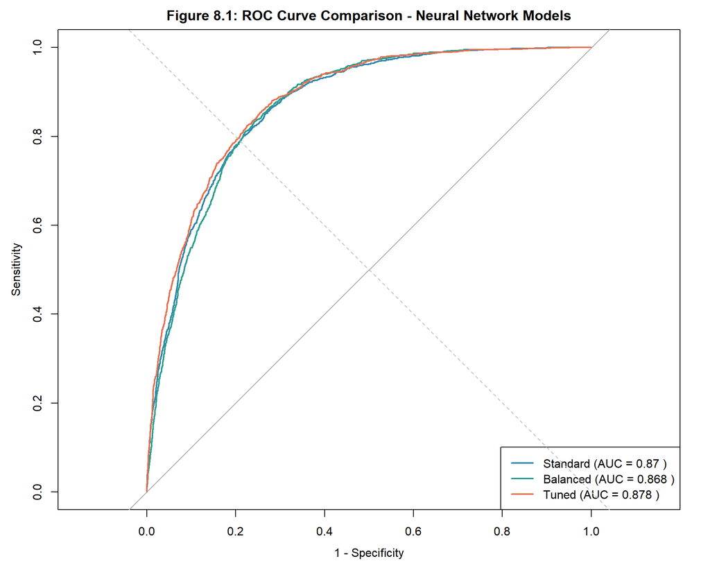

```r
# Plot ROC curves for all ANN variants
plot(roc_standard, col = colors$primary, lwd = 2,
     main = "Figure 8.1: ROC Curve Comparison - Neural Network Models",
     legacy.axes = TRUE)
plot(roc_balanced, col = colors$success, lwd = 2, add = TRUE)
plot(roc_tuned, col = colors$danger, lwd = 2, add = TRUE)

# Legend
legend("bottomright",
       legend = c(paste("Standard (AUC =", round(auc(roc_standard), 3), ")"),
                  paste("Balanced (AUC =", round(auc(roc_balanced), 3), ")"),
                  paste("Tuned (AUC =", round(auc(roc_tuned), 3), ")")),
       col = c(colors$primary, colors$success, colors$danger),
       lwd = 2)

abline(a = 0, b = 1, lty = 2, col = "gray")
```

## 8.8 Neural Network Architecture Summary

```r
# Simple text-based architecture summary
cat("Neural Network Architecture Summary\n")
```

```
## Neural Network Architecture Summary
```

```r
cat("======================================\n\n")
cat("Input Layer:\n")
```

```
## Input Layer:
```

```r
cat("  - Number of features:", length(feature_names), "\n")
```

```
##   - Number of features: 22
```

```r
cat("  - Top 10 features by importance:\n")
```

```
##   - Top 10 features by importance:
```

```r
for(i in 1:min(10, length(feature_names))) {
  cat("    ", i, ".", feature_names[i], "\n")
}
```

```
##      1 . education_num
##      2 . age
##      3 . hours_per_week
##      4 . fnlwgt
##      5 . relationshipHusband
##      6 . relationshipNot.in.family
##      7 . relationshipOwn.child
##      8 . relationshipUnmarried
##      9 . marital_statusMarried.civ.spouse
##      10 . marital_statusNever.married
```

```r
cat("\nHidden Layer:\n")
```

```
##
## Hidden Layer:
```

```r
cat("  - Number of nodes:", best_size, "\n")
```

```
##   - Number of nodes: 3
```

```r
cat("  - Activation function: Sigmoid (logistic)\n")
```

```
##   - Activation function: Sigmoid (logistic)
```

```r
cat("\nOutput Layer:\n")
```

```
##
## Output Layer:
```

```r
cat("  - Number of nodes: 1\n")
```

```
##   - Number of nodes: 1
```

```r
cat("  - Activation function: Linear\n")
```

```
##   - Activation function: Linear
```

```r
cat("  - Output interpretation: Probability of income >50K\n")
```

```
##   - Output interpretation: Probability of income >50K
```

```r
cat("\nTraining Parameters:\n")
```

```
##
## Training Parameters:
```

```r
cat("  - Weight decay (regularization): 0.5\n")
```

```
##   - Weight decay (regularization): 0.5
```

```r
cat("  - Maximum iterations: 200\n")
```

```
##   - Maximum iterations: 200
```

```r
cat("  - Convergence status:", ifelse(exists("nnet_tuned") && nnet_tuned$convergence == 0, "Converged", "Partial convergence"), "\n")
```

```
##   - Convergence status: Converged
```

## 8.9 Store Results for Main Comparison

```r
# Store results for Section 9
standard_nn_accuracy <- ann_standard_metrics$Value[1]
standard_nn_sensitivity <- ann_standard_metrics$Value[2]
standard_nn_specificity <- ann_standard_metrics$Value[3]
standard_nn_balanced_acc <- ann_standard_metrics$Value[4]
standard_nn_auc <- ann_standard_metrics$Value[5]

balanced_nn_accuracy <- ann_balanced_metrics$Value[1]
balanced_nn_sensitivity <- ann_balanced_metrics$Value[2]
balanced_nn_specificity <- ann_balanced_metrics$Value[3]
balanced_nn_balanced_acc <- ann_balanced_metrics$Value[4]
balanced_nn_auc <- ann_balanced_metrics$Value[5]

tuned_nn_accuracy <- ann_tuned_metrics$Value[2]
tuned_nn_sensitivity <- ann_tuned_metrics$Value[3]
tuned_nn_specificity <- ann_tuned_metrics$Value[4]
tuned_nn_balanced_acc <- ann_tuned_metrics$Value[5]
tuned_nn_auc <- ann_tuned_metrics$Value[6]

# Create compatibility objects for Section 9
ann_metrics <- ann_standard_metrics
ann_bal_metrics <- ann_balanced_metrics
tuned_metrics <- ann_tuned_metrics

print("Results stored for comprehensive comparison")
```

```
## [1] "Results stored for comprehensive comparison"
```

```r
print(paste("   - Standard NN Balanced Accuracy:", standard_nn_balanced_acc, "%"))
```

```
## [1] "   - Standard NN Balanced Accuracy: 72.82 %"
```

```r
print(paste("   - Balanced NN Balanced Accuracy:", balanced_nn_balanced_acc, "%"))
```

```
## [1] "   - Balanced NN Balanced Accuracy: 76.15 %"
```

```r
print(paste("   - Tuned NN Balanced Accuracy:", tuned_nn_balanced_acc, "%"))
```

```
## [1] "   - Tuned NN Balanced Accuracy: 73.16 %"
```

```r
# Export ANN results for use in later chapters
best_ann_idx <- which.max(ann_comparison$Balanced_Accuracy)
best_ann_model <- ann_comparison$Model[best_ann_idx]
best_ann_balanced_acc <- ann_comparison$Balanced_Accuracy[best_ann_idx]
best_ann_auc <- ann_comparison$AUC[best_ann_idx]

print("ANN results exported for later chapters")
```

```
## [1] "ANN results exported for later chapters"
```

```r
print(paste("   - Best ANN model:", best_ann_model))
```

```
## [1] "   - Best ANN model: Balanced NN"
```

```r
print(paste("   - Balanced Accuracy:", best_ann_balanced_acc, "%"))
```

```
## [1] "   - Balanced Accuracy: 76.15 %"
```

```r
print(paste("   - AUC:", best_ann_auc))
```

```
## [1] "   - AUC: 0.868"
```

# 9. Logistic Regression and K-Nearest Neighbors Models

## 9.1 Data Preparation for Logistic Regression and KNN

```r
# Prepare data for Logistic Regression and KNN
# These models require numerical inputs, so we'll create dummy variables

# Create a dataset suitable for Logistic Regression and KNN
# Select the engineered features
additional_model_data <- adult_cleaned[, c("age", "fnlwgt_log", "education_num",
                                           "capital_gain_log", "capital_loss_log",
                                           "hours_winsorized", "has_capital_gain",
                                           "has_capital_loss", "income")]

# Add dummy variables for categorical predictors
categorical_for_dummy <- adult_cleaned[, categorical_cols]
dummy_matrix <- model.matrix(~ . - 1, data = categorical_for_dummy)
dummy_df <- as.data.frame(dummy_matrix)

# Clean column names
names(dummy_df) <- make.names(names(dummy_df))

# Combine with numerical features
additional_model_data <- cbind(additional_model_data, dummy_df)

# Remove any columns with near-zero variance
nzv <- nearZeroVar(additional_model_data)
if(length(nzv) > 0) {
  additional_model_data <- additional_model_data[, -nzv]
}

# Define numerical columns for scaling
num_cols <- c("age", "fnlwgt_log", "education_num", "capital_gain_log",
              "capital_loss_log", "hours_winsorized")

# Create a copy for KNN with scaled features
knn_data <- additional_model_data

# Apply scaling only to numerical columns that exist
num_cols_present <- num_cols[num_cols %in% names(knn_data)]
if(length(num_cols_present) > 0) {
  knn_data[, num_cols_present] <- scale(knn_data[, num_cols_present])
}

# Create train/test splits
set.seed(256)
sample_idx_add <- sample(1:nrow(additional_model_data), 0.8 * nrow(additional_model_data))

# For Logistic Regression (use original data, not scaled)
train_logistic <- additional_model_data[sample_idx_add, ]
test_logistic <- additional_model_data[-sample_idx_add, ]

# For KNN (with scaled features)
train_knn <- knn_data[sample_idx_add, ]
test_knn <- knn_data[-sample_idx_add, ]

# Ensure income is a factor
train_logistic$income <- as.factor(train_logistic$income)
test_logistic$income <- as.factor(test_logistic$income)
train_knn$income <- as.factor(train_knn$income)
test_knn$income <- as.factor(test_knn$income)

print("Data prepared for Logistic Regression and KNN:")
```

```
## [1] "Data prepared for Logistic Regression and KNN:"
```

```r
print(paste("   - Logistic Regression training set:", nrow(train_logistic), "rows"))
```

```
## [1] "   - Logistic Regression training set: 26029 rows"
```

```r
print(paste("   - Logistic Regression testing set:", nrow(test_logistic), "rows"))
```

```
## [1] "   - Logistic Regression testing set: 6508 rows"
```

```r
print(paste("   - KNN training set:", nrow(train_knn), "rows"))
```

```
## [1] "   - KNN training set: 26029 rows"
```

```r
print(paste("   - KNN testing set:", nrow(test_knn), "rows"))
```

```
## [1] "   - KNN testing set: 6508 rows"
```

```r
print(paste("   - Features after dummy encoding:", ncol(train_logistic) - 1))
```

```
## [1] "   - Features after dummy encoding: 28"
```

## 9.2 Logistic Regression Models

### 9.2.1 Standard Logistic Regression

```r
# Train standard logistic regression model
logistic_model <- glm(income ~ .,
                      data = train_logistic,
                      family = binomial(link = "logit"))

# Make predictions
prob_logistic <- predict(logistic_model, test_logistic, type = "response")
pred_logistic <- ifelse(prob_logistic > 0.5, ">50K", "<=50K")
pred_logistic <- factor(pred_logistic, levels = levels(test_logistic$income))

# Evaluation
eval_logistic <- confusionMatrix(pred_logistic, test_logistic$income)
roc_logistic <- roc(test_logistic$income, prob_logistic)

# Extract metrics
logistic_metrics <- data.frame(
  Metric = c("Accuracy", "Sensitivity (<=50K)", "Specificity (>50K)",
             "Balanced Accuracy", "AUC"),
  Value = c(
    round(eval_logistic$overall["Accuracy"] * 100, 2),
    round(eval_logistic$byClass["Sensitivity"] * 100, 2),
    round(eval_logistic$byClass["Specificity"] * 100, 2),
    round(eval_logistic$byClass["Balanced Accuracy"] * 100, 2),
    round(auc(roc_logistic), 3)
  )
)

knitr::kable(logistic_metrics,
      caption = "Table 9.1: Standard Logistic Regression Performance")
```

Table 9.1: Standard Logistic Regression Performance

|  | Metric | Value |
| --- | --- | --- |
| Accuracy | Accuracy | 83.280 |
| Sensitivity | Sensitivity (<=50K) | 92.320 |
| Specificity | Specificity (>50K) | 54.560 |
| Balanced Accuracy | Balanced Accuracy | 73.440 |
|  | AUC | 0.886 |

### 9.2.2 Balanced Logistic Regression

```r
# Create balanced training set for logistic regression
set.seed(256)
train_logistic_balanced <- downSample(x = train_logistic[, -which(names(train_logistic) == "income")],
                                       y = train_logistic$income,
                                       yname = "income")

# Train balanced logistic regression
logistic_balanced <- glm(income ~ .,
                         data = train_logistic_balanced,
                         family = binomial(link = "logit"))

# Make predictions with custom threshold
prob_logistic_bal <- predict(logistic_balanced, test_logistic, type = "response")
custom_threshold <- 0.7
pred_logistic_bal <- ifelse(prob_logistic_bal > custom_threshold, ">50K", "<=50K")
pred_logistic_bal <- factor(pred_logistic_bal, levels = levels(test_logistic$income))

# Evaluation
eval_logistic_bal <- confusionMatrix(pred_logistic_bal, test_logistic$income)
roc_logistic_bal <- roc(test_logistic$income, prob_logistic_bal)

# Extract metrics
logistic_bal_metrics <- data.frame(
  Metric = c("Accuracy", "Sensitivity (<=50K)", "Specificity (>50K)",
             "Balanced Accuracy", "AUC"),
  Value = c(
    round(eval_logistic_bal$overall["Accuracy"] * 100, 2),
    round(eval_logistic_bal$byClass["Sensitivity"] * 100, 2),
    round(eval_logistic_bal$byClass["Specificity"] * 100, 2),
    round(eval_logistic_bal$byClass["Balanced Accuracy"] * 100, 2),
    round(auc(roc_logistic_bal), 3)
  )
)

knitr::kable(logistic_bal_metrics,
      caption = "Table 9.2: Balanced Logistic Regression Performance")
```

Table 9.2: Balanced Logistic Regression Performance

|  | Metric | Value |
| --- | --- | --- |
| Accuracy | Accuracy | 83.210 |
| Sensitivity | Sensitivity (<=50K) | 89.390 |
| Specificity | Specificity (>50K) | 63.540 |
| Balanced Accuracy | Balanced Accuracy | 76.470 |
|  | AUC | 0.886 |

### 9.2.3 Logistic Regression Coefficients

```r
# Extract and display important coefficients from balanced model
coef_summary <- summary(logistic_balanced)$coefficients
coef_df <- data.frame(
  Feature = rownames(coef_summary),
  Coefficient = round(coef_summary[, "Estimate"], 3),
  Odds_Ratio = round(exp(coef_summary[, "Estimate"]), 3),
  P_Value = format(coef_summary[, "Pr(>|z|)"], scientific = TRUE, digits = 3)
)

# Sort by absolute coefficient value
coef_df <- coef_df[order(abs(coef_df$Coefficient), decreasing = TRUE), ]

# Display top 15 most important features
knitr::kable(head(coef_df, 15),
      caption = "Table 9.3: Top 15 Logistic Regression Coefficients (Balanced Model)")
```

Table 9.3: Top 15 Logistic Regression Coefficients (Balanced Model)

|  | Feature | Coefficient | Odds_Ratio | P_Value |
| --- | --- | --- | --- | --- |
| (Intercept) | (Intercept) | -9.674 | 0.000 | 1.48e-59 |
| marital_statusMarried.civ.spouse | marital_statusMarried.civ.spouse | 2.310 | 10.075 | 1.92e-26 |
| has_capital_gain1 | has_capital_gain1 | 1.624 | 5.076 | 2.17e-78 |
| relationshipOwn.child | relationshipOwn.child | -1.015 | 0.362 | 2.45e-05 |
| occupationOther.service | occupationOther.service | -0.784 | 0.457 | 1.58e-09 |
| occupationExec.managerial | occupationExec.managerial | 0.750 | 2.117 | 1.62e-20 |
| occupationProf.specialty | occupationProf.specialty | 0.574 | 1.775 | 8.07e-11 |
| workclassSelf.emp.not.inc | workclassSelf.emp.not.inc | -0.548 | 0.578 | 1.62e-07 |
| occupationMachine.op.inspct | occupationMachine.op.inspct | -0.384 | 0.681 | 1.14e-03 |
| marital_statusNever.married | marital_statusNever.married | -0.359 | 0.698 | 2.40e-04 |
| relationshipNot.in.family | relationshipNot.in.family | 0.336 | 1.399 | 1.16e-01 |
| education_num | education_num | 0.293 | 1.341 | 8.80e-71 |
| native_countryUnited.States | native_countryUnited.States | 0.261 | 1.298 | 9.42e-03 |
| occupationSales | occupationSales | 0.235 | 1.265 | 7.10e-03 |
| educationSome.college | educationSome.college | 0.205 | 1.227 | 9.27e-03 |

### 9.2.4 ROC Curve for Logistic Regression

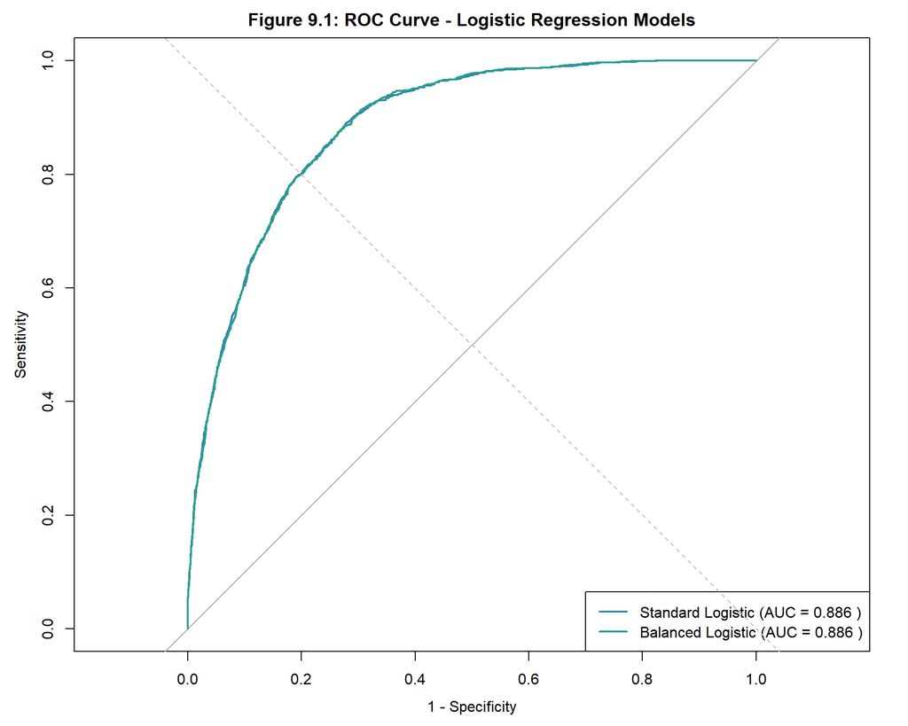

```r
# Plot ROC curves for both logistic regression models
plot(roc_logistic, col = colors$primary, lwd = 2,
     main = "Figure 9.1: ROC Curve - Logistic Regression Models",
     legacy.axes = TRUE)
plot(roc_logistic_bal, col = colors$success, lwd = 2, add = TRUE)

# Add legend
legend("bottomright",
       legend = c(paste("Standard Logistic (AUC =", round(auc(roc_logistic), 3), ")"),
                  paste("Balanced Logistic (AUC =", round(auc(roc_logistic_bal), 3), ")")),
       col = c(colors$primary, colors$success),
       lwd = 2)

abline(a = 0, b = 1, lty = 2, col = "gray")
```

## 9.3 K-Nearest Neighbors (KNN) - Optimized

### 9.3.1 Prepare Data for KNN

```r
# KNN requires all predictors to be numeric
# Create clean numeric datasets for KNN

# Function to safely convert to numeric
safe_as_numeric <- function(x) {
  if(is.factor(x)) {
    return(as.numeric(as.character(x)))
  } else if(is.character(x)) {
    return(as.numeric(x))
  } else {
    return(as.numeric(x))
  }
}

# Convert training and test sets to all numeric
train_knn_num <- train_knn
test_knn_num <- test_knn

# Convert all non-income columns to numeric
for(col in names(train_knn_num)) {
  if(col != "income") {
    train_knn_num[[col]] <- safe_as_numeric(train_knn_num[[col]])
    test_knn_num[[col]] <- safe_as_numeric(test_knn_num[[col]])

    # Fill NA values with column means
    if(any(is.na(train_knn_num[[col]]))) {
      col_mean <- mean(train_knn_num[[col]], na.rm = TRUE)
      train_knn_num[[col]][is.na(train_knn_num[[col]])] <- col_mean
    }
    if(any(is.na(test_knn_num[[col]]))) {
      col_mean <- mean(train_knn_num[[col]], na.rm = TRUE)
      test_knn_num[[col]][is.na(test_knn_num[[col]])] <- col_mean
    }
  }
}

print("Data prepared for KNN:")
```

```
## [1] "Data prepared for KNN:"
```

```r
print(paste("   - Training features:", ncol(train_knn_num) - 1))
```

```
## [1] "   - Training features: 28"
```

```r
print(paste("   - Testing features:", ncol(test_knn_num) - 1))
```

```
## [1] "   - Testing features: 28"
```

### 9.3.2 Finding Optimal K

```r
# Test different k values using validation split
set.seed(256)
k_values <- seq(1, 31, by = 2)
knn_accuracies <- data.frame(k = k_values, Accuracy = NA, Balanced_Accuracy = NA)

# Create validation split
val_idx <- sample(1:nrow(train_knn_num), 0.2 * nrow(train_knn_num))
train_knn_sub <- train_knn_num[-val_idx, ]
val_knn <- train_knn_num[val_idx, ]

for(i in seq_along(k_values)) {
  k <- k_values[i]

  tryCatch({
    pred_val <- class::knn(train = train_knn_sub[, !names(train_knn_sub) %in% "income"],
                           test = val_knn[, !names(val_knn) %in% "income"],
                           cl = train_knn_sub$income,
                           k = k)

    pred_val <- factor(pred_val, levels = levels(train_knn_sub$income))
    cm <- confusionMatrix(pred_val, val_knn$income)
    knn_accuracies$Accuracy[i] <- cm$overall["Accuracy"]
    knn_accuracies$Balanced_Accuracy[i] <- cm$byClass["Balanced Accuracy"]
  }, error = function(e) {
    knn_accuracies$Accuracy[i] <- NA
    knn_accuracies$Balanced_Accuracy[i] <- NA
  })
}

# Find optimal k (using balanced accuracy)
optimal_k <- knn_accuracies$k[which.max(knn_accuracies$Balanced_Accuracy)]
print(paste("Optimal k value (based on balanced accuracy):", optimal_k))
```

```
## [1] "Optimal k value (based on balanced accuracy): 19"
```

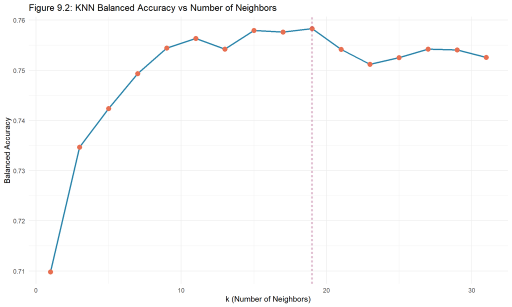

```r
# Plot accuracy vs k
ggplot(na.omit(knn_accuracies), aes(x = k, y = Balanced_Accuracy)) +
  geom_line(color = colors$primary, size = 1) +
  geom_point(color = colors$danger, size = 3) +
  geom_vline(xintercept = optimal_k, linetype = "dashed", color = colors$secondary) +
  labs(title = "Figure 9.2: KNN Balanced Accuracy vs Number of Neighbors",
       x = "k (Number of Neighbors)",
       y = "Balanced Accuracy") +
  theme_minimal()
```